# Machine Learning course project

Lorena Zuniga

December 25, 2015

## Context

Using devices such as Jawbone Up, Nike FuelBand, and Fitbit it is now possible to collect a large amount of data about personal activity relatively inexpensively. These type of devices are part of the quantified self movement – a group of enthusiasts who take measurements about themselves regularly to improve their health, to find patterns in their behavior, or because they are tech geeks. One thing that people regularly do is quantify how much of a particular activity they do, but they rarely quantify how well they do it.

## The goal

It is to use data from accelerometers on the belt, forearm, arm, and dumbell of 6 participants and predict the manner in which they did the exercise.

## The data

The dataset was provided by this source: http://groupware.les.inf.puc-rio.br/har

## The process

### 1. First load the required libraries

### 2. Load the data for training and the final 20 tests

```r
 trData<- read.csv("data/pml-training.csv",na.strings=c("NA","#DIV/0!",""))
 tstData <- read.csv("data/pml-testing.csv",na.strings=c("NA","#DIV/0!",""))
```

### 3. Transforming the data (both training and test)

```r
 dropColumns<-c('X', 'user_name','raw_timestamp_part_1', 'raw_timestamp_part_2','cvtd_timestamp','new_window')
 trData<- trData[,!(names(trData) %in% dropColumns)]
 tstData<- tstData[,!(names(tstData) %in% dropColumns)]
```

In order to work with the cleanest data the columns where the NAs percentaje is greater than 40% were removed from the original training and test datasets

```r
 trData<-trData[,colSums(is.na(trData)) < nrow(trData) * 0.4]
 dim(trData)
```

```
## [1] 19622    54
```

```r
 tstData<-tstData[,colSums(is.na(tstData)) < nrow(tstData) * 0.4]
 dim(tstData)
```

```
## [1] 20 54
```

### 4.Creating the training and test sets

```r
 set.seed(1234)
 inTrain <- createDataPartition(y=trData$classe, p=0.7,list=FALSE)

 training <- trData[inTrain,]
 testing <- trData[-inTrain,]
```

### 5. First model with a simple decision tree

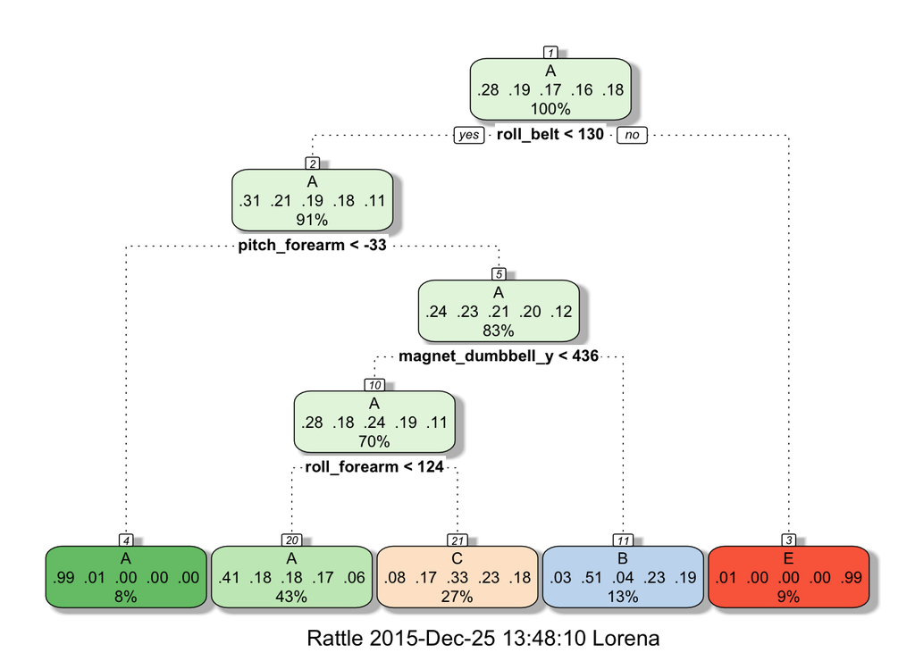

```r
 model <- train(training$classe ~ . , method='rpart',data=training)
 fancyRpartPlot(model$finalModel)
```

```r
 predictionsDT <- predict(model,testing)
```

Viewing the confusion matrix and the accuracy of the model

```r
 confusionMatrix(predictionsDT,testing$classe)
```

```
## Confusion Matrix and Statistics
##
##           Reference
## Prediction    A    B    C    D    E
##          A 1530  486  493  452  168
##          B   35  379   31  164  145
##          C  105  274  502  348  302
##          D    0    0    0    0    0
##          E    4    0    0    0  467
##
## Overall Statistics
##
##                Accuracy : 0.489
##                  95% CI : (0.4762, 0.5019)
##     No Information Rate : 0.2845
##     P-Value [Acc > NIR] : < 2.2e-16
##
##                   Kappa : 0.3311
##  Mcnemar's Test P-Value : NA
##
## Statistics by Class:
##
##                      Class: A Class: B Class: C Class: D Class: E
## Sensitivity            0.9140   0.3327   0.4893   0.0000  0.43161
## Specificity            0.6203   0.9210   0.7882   1.0000  0.99917
## Pos Pred Value         0.4890   0.5027   0.3279      NaN  0.99151
## Neg Pred Value         0.9478   0.8519   0.8797   0.8362  0.88641
## Prevalence             0.2845   0.1935   0.1743   0.1638  0.18386
## Detection Rate         0.2600   0.0644   0.0853   0.0000  0.07935
## Detection Prevalence   0.5317   0.1281   0.2602   0.0000  0.08003
## Balanced Accuracy      0.7671   0.6269   0.6388   0.5000  0.71539
```

### A second model using RandomForests

```r
 model2<-randomForest(classe ~ . ,data=training)

 # predictions with randomForest
 predictionsRF <- predict(model2,testing)
```

Showing the confusion matrix and the model’s accuracy

```r
confusionMatrix(predictionsRF,testing$classe)
```

```
## Confusion Matrix and Statistics
##
##           Reference
## Prediction    A    B    C    D    E
##          A 1674    3    0    0    0
##          B    0 1136    3    0    0
##          C    0    0 1022    4    0
##          D    0    0    1  960    0
##          E    0    0    0    0 1082
##
## Overall Statistics
##
##                Accuracy : 0.9981
##                  95% CI : (0.9967, 0.9991)
##     No Information Rate : 0.2845
##     P-Value [Acc > NIR] : < 2.2e-16
##
##                   Kappa : 0.9976
##  Mcnemar's Test P-Value : NA
##
## Statistics by Class:
##
##                      Class: A Class: B Class: C Class: D Class: E
## Sensitivity            1.0000   0.9974   0.9961   0.9959   1.0000
## Specificity            0.9993   0.9994   0.9992   0.9998   1.0000
## Pos Pred Value         0.9982   0.9974   0.9961   0.9990   1.0000
## Neg Pred Value         1.0000   0.9994   0.9992   0.9992   1.0000
## Prevalence             0.2845   0.1935   0.1743   0.1638   0.1839
## Detection Rate         0.2845   0.1930   0.1737   0.1631   0.1839
## Detection Prevalence   0.2850   0.1935   0.1743   0.1633   0.1839
## Balanced Accuracy      0.9996   0.9984   0.9976   0.9978   1.0000
```

### 6. predicting the values for the 20 tests using the second model (random forest)

Given the accuracy of the first model (0.48) vs the second one (0.99), the 20 records were tested with the random Forest model

```r
 finalPredictionsRF <- predict(model2,tstData,type='class')
```

### The code provided to generate the files for submission

```r
 pml_write_files <-function(x){
   n = length(x)
   for(i in 1:n)
   {
     filename = paste0("problem_id_",i,".txt")
     write.table(x[i],file=filename,quote=FALSE,row.names=FALSE,col.names = FALSE)
   }

 }
```

### 7. Creating the output files

```r
 pml_write_files(finalPredictionsRF)
```